# Machine Learning on Weight Lifting Dataset

Nguyen Son Linh

6/8/2020

# Executive summary

This project aims to predict how well a participant does the weight lifting excercise using data from accelerometers on their body.

Consequently, feedback can be given to improve performance.

# Setup

## Packages

```r
library(caret)
library(knitr)
library(rpart)
library(randomForest)
library(ggplot2)
library(dplyr)
```

For this project, we are going to need some machine learning packages and ggplot2 for better visualisation.

## Data

```r
if (!file.exists("pml-training.csv"))
  { download.file("https://d396qusza40orc.cloudfront.net/predmachlearn/pml-training.csv",
  destfile="./pml-training.csv")
  }
if (!file.exists("pml-testing.csv"))
  { download.file("https://d396qusza40orc.cloudfront.net/predmachlearn/pml-testing.csv",
  destfile="./pml-testing.csv")
  }
training <- read.csv("pml-training.csv")
testing <- read.csv("pml-testing.csv")
```

# Analysis

## About the data set

The data is sourced from http://groupware.les.inf.puc-rio.br/har.

As per the description, 6 male participants in the 20-28 age group were asked perform one set of 10 repetitions of the Unilateral Dumbbell Biceps Curl in five different fashions, with the first one the correct way:  
- exactly according to the specification (Class A)  
- throwing the elbows to the front (Class B)  
- lifting the dumbbell only halfway (Class C)  
- lowering the dumbbell only halfway (Class D)  
- throwing the hips to the front (Class E)

Sensors were attached to the dumbbell, participants’ arm, forearm and belt. Each sensor in their sliding window collected data for:  
- Euler angles (roll, pitch and yaw)  
- For each Euler angle: mean, variance, standard deviation, max, min, amplitude, kurtosis and skewness  
- Raw accelerometer, gyroscope and magnetometer readings

## Exploratory analysis

There are 19622 observations and 160 variables in the **pmltrain** dataset.

There are 20 observations and 160 variables in the **pmltest** dataset.

The data has already been divided into training and testing sets, however we would expect a higher ratio instead of the given test set of 20 observations. Additionally the **pmltest** does not have the outcome variable _classe- therefore will be used in the final prediction ‘test’.

*After EDA, the training dataset will be splitted into training and testing dataset.*

Now we will look at some statistics about the classe variable and predictors.

```r
# Convert to factor
training$classe <- as.factor(training$classe)

kable(summary(training$classe))
```

|  | x |
| --- | --- |
| A | 5580 |
| B | 3797 |
| C | 3422 |
| D | 3216 |
| E | 3607 |

It is easily seen that A is the most frequent class.

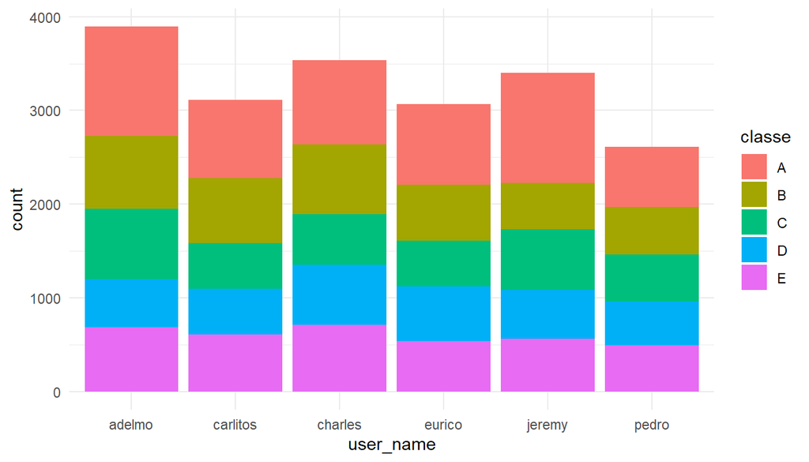

```r
training %>% ggplot(aes(user_name)) +
    geom_bar(aes(fill = classe)) +
    theme_minimal()
```

From the above barplot, participant does not seem to be a factor.

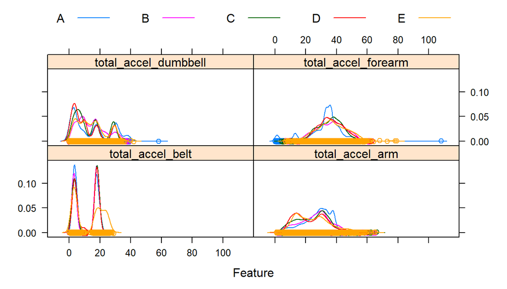

```r
featurePlot(x = training[,c("total_accel_belt", "total_accel_arm", "total_accel_dumbbell","total_accel_forearm")],
            y = training$classe,
            plot = "density",
            type = c("p", "smooth"),
            auto.key = list(columns = 5))
```

## Modeling

First, we split the training data into train and test sets. Also rename the original testing data.

```r
quiz_data <- testing
inTrain <- createDataPartition(training$classe, p = 0.6, list = F)
testing <- training[-inTrain, ]
training <- training[inTrain, ]
```

Now we clean the data to remove unnecessary variables.

```r
testing <- testing %>%
  select(starts_with("total") | starts_with("accel") | classe |
         starts_with("pitch") | starts_with("roll") | new_window |
         starts_with("yaw") | num_window)

training <- training %>%
  select(starts_with("total") | starts_with("accel") | classe |
         starts_with("pitch") | starts_with("roll") | new_window |
         starts_with("yaw") | num_window)
```

Near-zero variance covariates shall also be removed.

```r
nsv <- nearZeroVar(training, saveMetrics = T)
kable(nsv[nsv$nzv == T, ])
```

|  | freqRatio | percentUnique | zeroVar | nzv |
| --- | --- | --- | --- | --- |
| new_window | 49.32479 | 0.0169837 | FALSE | TRUE |

```r
training <- training %>%
  select(-starts_with("new_window"))

testing <- testing %>%
  select(-starts_with("new_window"))
```

Any integer values now must be converted to numeric for modelling to work.

```r
index <- which(names(training) == "classe")
training[, -index] <- lapply(training[, -index], as.numeric)

testing[, -index] <- lapply(testing[, -index], as.numeric)
```

Highly correlateed variables should be reweighted. Cutoff is chosen at 0.8 .

```r
cors <-  abs(cor(training[, -index]))
high_cors <- findCorrelation(cors, cutoff = .8)
kable(training[0, high_cors])
```

| accel_belt_z | pitch_forearm | accel_belt_y | accel_dumbbell_z | accel_belt_x | accel_dumbbell_x |
| --- | --- | --- | --- | --- | --- |

We can utilise the preProcess function of the caret package to do that.

```r
preProc <- preProcess(training, method = c("center", "scale"))

preProc
```

```
## Created from 11776 samples and 30 variables
##
## Pre-processing:
##   - centered (29)
##   - ignored (1)
##   - scaled (29)
```

Imputation and dummy variables are not needed here since all predictors left are numerical.

**MODEL BUILDING**

From our EDA we can deduce that a non-linear model is required as we know the outcome variable, i.e *classe*.

With the vastness of the data, classification tree and random forest are the two most promsing methods.

Let’s attempt the classification tree method.

```r
set.seed(123)
model_tree <- rpart(classe ~ ., data = training, method = "class")
predictions_tree <- predict(model_tree, testing, type = "class")
```

The accuracy of this method is 0.7629365

Time for random foresting. We do bootstrapping here as well as k-fold cross validation.

```r
trControl <- trainControl(method = "cv", number = 3)
model_forest <- train(classe ~ ., data = training, method = "rf",
                      trControl = trControl)
```

The accuracy for the random forest is 0.9982157.

## Conclusion

- We built 2 models and come to a conclusion that random forest is much more predictive, albeit more time-consuming.
- Based on the estimated accuracy, the chance of missclassification using the random forest model is slim.